# 10 Workshop – Zero-Truncated and Zero-Inflated Models

Xanthe Walker

2025-08-06

## Introduction

Many ecological count datasets include zeros — and in some cases, **only non-zero values are observed**, or **there are more zeros than expected** under common distributions like the Poisson or negative binomial. This workshop introduces two modeling approaches designed for such data:

- **Part 1: Zero-Truncated Models** – when zero counts are not observed (e.g., only positive counts recorded)
- **Part 2: Zero-Inflated and Hurdle Models** – when there are excess zeros in the dataset, due to structural, observational, or sampling processes

We will use real ecological datasets and explore models using `glmmTMB` and `DHARMa`.

## Part 1: Zero-Truncated Models – Snakes Dataset

### Background

We will analyze data on the number of days that road-killed snakes remained visible on roads before decomposing or being removed. This variable (`N_days`) is a **count** with **no observed zeros** (i.e., we only observe carcasses that were present at least 1 day). Therefore, this dataset is a classic candidate for **zero-truncated modeling**

The predictors include: - `Tot_Rain`: Total rainfall (mm) - `Road_Loc`: Location on the road (lane or shoulder)

We will: - Explore the distribution of the response - Fit and compare standard and truncated negative binomial models - Interpret model results and discuss when zero-truncated models are necessary

### Load data

```r
Snakes <- read.csv("../../Data files/snakes.csv")
```

### Explore data

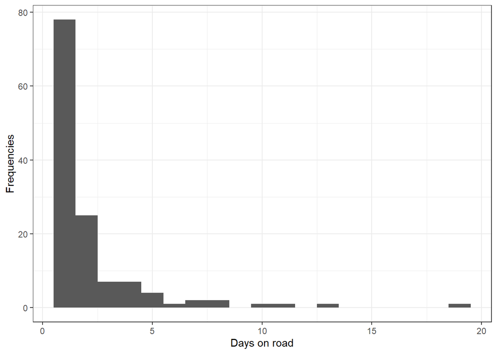

```r
ggplot(Snakes, aes(x = N_days)) + geom_histogram(binwidth = 1)+labs(y="Frequencies",x = "Days on road")+theme_bw()
```

```r
mean(Snakes$N_days)
```

```
## [1] 2.2
```

```r
var(Snakes$N_days)
```

```
## [1] 6.486822
```

**Note:** - The **mean** number of days is lower than the **variance**, indicating **overdispersion**. - This suggests a negative binomial model may be more appropriate than Poisson. - Zero counts are absent due to study design – we only observe carcasses that remained on the road for ≥1 day.

### Fit standard negative binomial model

```r
nb_tmb <- glmmTMB(N_days ~ Road_Loc + Tot_Rain, data = Snakes, family = nbinom2)
summary(nb_tmb)
```

```
##  Family: nbinom2  ( log )
## Formula:          N_days ~ Road_Loc + Tot_Rain
## Data: Snakes
##
##       AIC       BIC    logLik -2*log(L)  df.resid
##     469.3     480.7    -230.6     461.3       126
##
##
## Dispersion parameter for nbinom2 family (): 4.15
##
## Conditional model:
##             Estimate Std. Error z value Pr(>|z|)
## (Intercept) 0.418101   0.107339   3.895 9.81e-05 ***
## Road_LocV   0.453524   0.151408   2.995  0.00274 **
## Tot_Rain    0.025127   0.005075   4.951 7.39e-07 ***
## ---
## Signif. codes:  0 '***' 0.001 '**' 0.01 '*' 0.05 '.' 0.1 ' ' 1
```

`nbinom2` assumes variance increases **quadratically** with the mean. `nbinom1` assumes variance increases **linearly**. `nbinom2` is more flexible and is typically used

Although the regular negative binomial model will run, we know that the data are zero truncated and so we should try a zero-truncated model instead.

### Fit a zero-truncated model

```r
ztnb_tmb <- glmmTMB(N_days ~ Road_Loc + Tot_Rain, data = Snakes, family = truncated_nbinom2)
summary(ztnb_tmb)
```

```
##  Family: truncated_nbinom2  ( log )
## Formula:          N_days ~ Road_Loc + Tot_Rain
## Data: Snakes
##
##       AIC       BIC    logLik -2*log(L)  df.resid
##     351.9     363.4    -172.0     343.9       126
##
##
## Dispersion parameter for truncated_nbinom2 family (): 1.27e-08
##
## Conditional model:
##               Estimate Std. Error z value Pr(>|z|)
## (Intercept)  -18.14719 9365.15795  -0.002 0.998454
## Road_LocV      1.14474    0.38568   2.968 0.002996 **
## Tot_Rain       0.07241    0.02150   3.368 0.000758 ***
## ---
## Signif. codes:  0 '***' 0.001 '**' 0.01 '*' 0.05 '.' 0.1 ' ' 1
```

**Zero-truncated models** account for the absence of zeros in the data. Parameter estimates will typically differ from standard NB models, especially when low counts dominate the data.

**Use AIC to compare model fit.** Lower AIC = better fit.

### Model comparison

```r
AIC(ztnb_tmb, nb_tmb)
```

```
##          df      AIC
## ztnb_tmb  4 351.9488
## nb_tmb    4 469.2788
```

```r
summary(ztnb_tmb)
```

```
##  Family: truncated_nbinom2  ( log )
## Formula:          N_days ~ Road_Loc + Tot_Rain
## Data: Snakes
##
##       AIC       BIC    logLik -2*log(L)  df.resid
##     351.9     363.4    -172.0     343.9       126
##
##
## Dispersion parameter for truncated_nbinom2 family (): 1.27e-08
##
## Conditional model:
##               Estimate Std. Error z value Pr(>|z|)
## (Intercept)  -18.14719 9365.15795  -0.002 0.998454
## Road_LocV      1.14474    0.38568   2.968 0.002996 **
## Tot_Rain       0.07241    0.02150   3.368 0.000758 ***
## ---
## Signif. codes:  0 '***' 0.001 '**' 0.01 '*' 0.05 '.' 0.1 ' ' 1
```

```r
tab_model(ztnb_tmb, show.se = TRUE, show.icc = FALSE)
```

|  | N_days |  |  |  |
| --- | --- | --- | --- | --- |
| Predictors | Incidence Rate Ratios | std. Error | CI | p |
| (Intercept) | 0.00 | 0.00 | 0.00 – Inf | 0.998 |
| Road Loc [V] | 3.14 | 1.21 | 1.48 – 6.69 | **0.003** |
| Tot Rain | 1.08 | 0.02 | 1.03 – 1.12 | **0.001** |
| (Intercept) | 1.00 |  | 1.00 – Inf |  |
| Observations | 130 |  |  |  |
| R<sup>2</sup> / R<sup>2</sup> adjusted | 1.000 / 1.000 |  |  |  |

**Interpreting coefficients in a truncated model:**  
The interpretation is similar to other GLMs — coefficients are on the log scale.  
Exponentiating them (`exp(coef)`) gives the **incidence rate ratio (IRR)**: the multiplicative change in expected count per 1-unit (or 1-SD) increase in the predictor.

For example:

```r
exp(fixef(ztnb_tmb)$cond)  # IRRs for the count part
```

```
##  (Intercept)    Road_LocV     Tot_Rain
## 1.314540e-08 3.141611e+00 1.075091e+00
```

- **Road_LocV:** `IRR ≈ 3.14` → snakes in location **V** (the shoulder) are expected to remain on the road about **3.14× longer** (≈ **+214%**) than the reference location, holding rainfall constant.
- **Tot_Rain:** `IRR ≈ 1.075` → each **1-unit increase** in total rainfall is associated with about a **7.5% increase** in expected days, holding road location constant.

> General rule: for any coefficient β, **IRR = exp(β)**. Percent change ≈ **(IRR − 1) × 100%**

## Part 2: Zero-Inflated and Hurdle Models – ParasiteCod Dataset

### Background

We will analyze data from a survey of parasites in cod fish collected along the coast of Finnmark, Norway. The response variable `Intensity` represents the **count of parasites per fish**, and many fish have **zero parasites**.

#### Possible explanations for zero counts include:

- **Species error** – fish is suitable, but the parasite is not there
- **Design error** – poor sampling effort (e.g., only sampled fish that were never exposed to the parasite)
- **Observer error** – parasites are present but undetected
- **Structural zeros** – a true zero. fish were in contact with parasite and parasite is note there.

Understanding which types of zeros are likely helps determine the right model: - **Zero-inflated models** assume some observations come from a separate process that generates extra zeros. - **Hurdle models** assume a two-step process: one determines presence/absence, another determines count.

### Load and prepare data

```r
ParasiteCod <- read.csv("../../Data files/ParasiteCod.csv")
ParasiteCod$fArea <- factor(ParasiteCod$Area)
ParasiteCod$fYear <- factor(ParasiteCod$Year)

# Remove missing values
ParasiteCod2 <- ParasiteCod %>%
  filter(!is.na(Intensity), !is.na(fArea), !is.na(fYear), !is.na(Length))
```

### Explore response

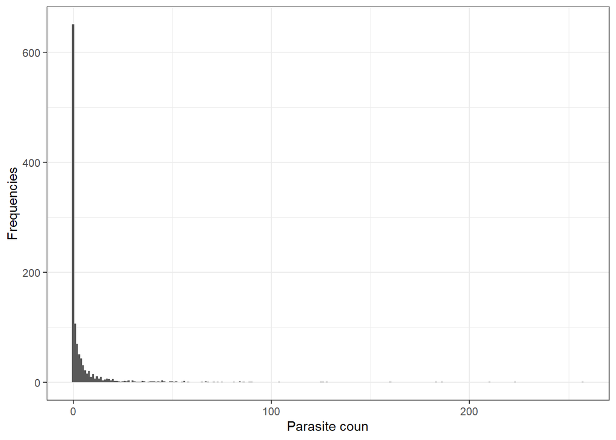

```r
ggplot(ParasiteCod2, aes(x = Intensity)) + geom_histogram(binwidth = 1)+labs(y="Frequencies",x = "Parasite coun")+theme_bw()
```

```r
mean(ParasiteCod2$Intensity)
```

```
## [1] 6.209068
```

```r
var(ParasiteCod2$Intensity)
```

```
## [1] 385.8025
```

**Note:** The distribution is highly zero-inflated and overdispersed. A standard Poisson model is likely a poor fit.

### Fit Zero-Inflated Poisson model

```r
Zip1 <- glmmTMB(Intensity ~ fArea*fYear + Length,
                ziformula = ~ fArea*fYear + Length,
                data = ParasiteCod2, family = poisson)
summary(Zip1)
```

```
##  Family: poisson  ( log )
## Formula:          Intensity ~ fArea * fYear + Length
## Zero inflation:             ~fArea * fYear + Length
## Data: ParasiteCod2
##
##       AIC       BIC    logLik -2*log(L)  df.resid
##   13687.1   13819.2   -6817.5   13635.1      1165
##
##
## Conditional model:
##                    Estimate Std. Error z value Pr(>|z|)
## (Intercept)       3.9553571  0.0609256   64.92  < 2e-16 ***
## fArea2            0.3131542  0.0712890    4.39 1.12e-05 ***
## fArea3           -0.2818600  0.0731399   -3.85 0.000116 ***
## fArea4            0.8221576  0.0458181   17.94  < 2e-16 ***
## fYear2000         0.1357711  0.0736022    1.84 0.065087 .
## fYear2001        -0.9146733  0.1936712   -4.72 2.33e-06 ***
## Length           -0.0368034  0.0009808  -37.52  < 2e-16 ***
## fArea2:fYear2000 -0.6000134  0.1343017   -4.47 7.91e-06 ***
## fArea3:fYear2000  0.8350359  0.1042241    8.01 1.13e-15 ***
## fArea4:fYear2000  0.2673232  0.0819237    3.26 0.001102 **
## fArea2:fYear2001  0.9711026  0.2102698    4.62 3.87e-06 ***
## fArea3:fYear2001  1.0106698  0.2115485    4.78 1.78e-06 ***
## fArea4:fYear2001  0.8913142  0.1974285    4.51 6.34e-06 ***
## ---
## Signif. codes:  0 '***' 0.001 '**' 0.01 '*' 0.05 '.' 0.1 ' ' 1
##
## Zero-inflation model:
##                   Estimate Std. Error z value Pr(>|z|)
## (Intercept)       0.008624   0.300300   0.029   0.9771
## fArea2            1.322968   0.286123   4.624 3.77e-06 ***
## fArea3            1.440239   0.245198   5.874 4.26e-09 ***
## fArea4           -0.306446   0.271867  -1.127   0.2597
## fYear2000        -0.392423   0.347442  -1.129   0.2587
## fYear2001         2.548300   0.439594   5.797 6.75e-09 ***
## Length           -0.008873   0.004786  -1.854   0.0637 .
## fArea2:fYear2000  0.063252   0.512411   0.123   0.9018
## fArea3:fYear2000 -0.852235   0.453818  -1.878   0.0604 .
## fArea4:fYear2000 -0.859451   0.594683  -1.445   0.1484
## fArea2:fYear2001 -2.622902   0.538744  -4.869 1.12e-06 ***
## fArea3:fYear2001 -2.634673   0.506101  -5.206 1.93e-07 ***
## fArea4:fYear2001 -2.431421   0.524340  -4.637 3.53e-06 ***
## ---
## Signif. codes:  0 '***' 0.001 '**' 0.01 '*' 0.05 '.' 0.1 ' ' 1
```

The `ziformula` uses a logistic regression model (binomial dist) to estimate the probability that an observation is from the **zero-inflation process**, which means it predicts whether an observation is an excess zero (i.e., zero from the zero-inflation process) or comes from the regular count-generating process. Setting it to `~1` assumes the zero-inflation is contant for all observations.

Before we can trust this summary output, we need to ensure that the model fits. We need to check if there is still overdispersion.

If the overdispersion in a Poisson GLM is caused by the excessive number of zeros, then the ZIP will take care of the overdispersion, and we are finished. If the overdispersion is not caused by the zeros, then ZIP is not the appropriate model.

```r
check_overdispersion(Zip1)
```

```
## # Overdispersion test
##
##  dispersion ratio =   6.170
##           p-value = < 0.001
```

```
## Overdispersion detected.
```

We can see that the data are still overdispersed. And we should try fitting a ZINB.

### Fit Zero-Inflated Negative Binomial (ZINB)

```r
Zinb1 <- glmmTMB(Intensity ~ fArea*fYear + Length,
                 ziformula = ~ fArea*fYear + Length,
                 data = ParasiteCod2, family = nbinom2)
```

The only thing that changed is the family that we specify. We then use AIC to compare the two model types.

### Model comparison

```r
AIC(Zip1, Zinb1)
```

```
##       df       AIC
## Zip1  26 13687.097
## Zinb1 27  4954.896
```

The zero-inflated negative binomial is a much better fit, but we should still check for overdispersion.

### Diagnostics and residual checks

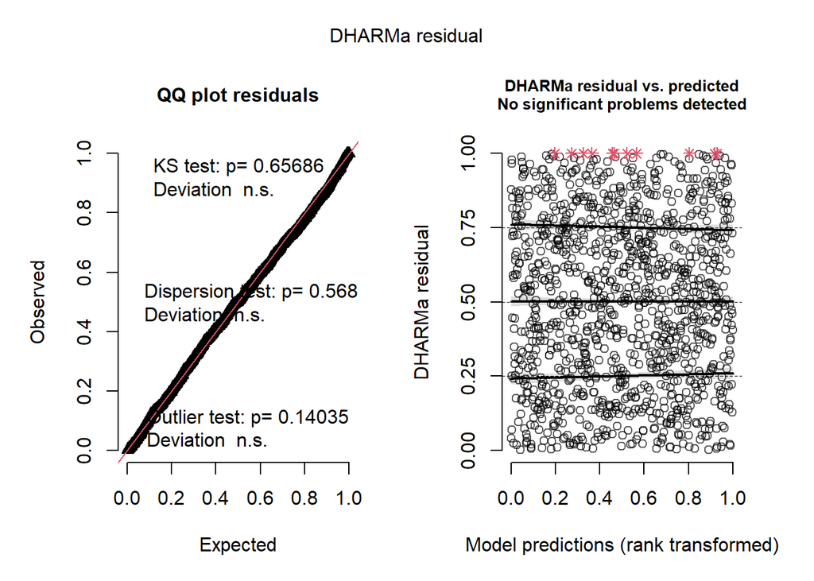

```r
simulationOutput <- simulateResiduals(Zinb1)
plot(simulationOutput)
```

```r
check_overdispersion(Zinb1)
```

```
## # Overdispersion test
##
##  dispersion ratio = 1.121
##           p-value = 0.568
```

```
## No overdispersion detected.
```

Although the model seems to fit the data well, we are not done yet. We need to complete model selection

### Model selection

We will compare the full model with no terms dropped to - Drop length from count model - Drop Area X Year from the count model - Drop length from the logistic model (or the zero versus non zero model) - Drop Area X Year from the logistic model

```r
Zinb2 <- glmmTMB(Intensity ~ fArea*fYear,
                 ziformula = ~ fArea*fYear + Length,
                 data = ParasiteCod2, family = nbinom2)
Zinb3 <- glmmTMB(Intensity ~ fArea+fYear+Length,
                 ziformula = ~ fArea*fYear + Length,
                 data = ParasiteCod2, family = nbinom2)

Zinb4 <- glmmTMB(Intensity ~ fArea*fYear + Length,
                 ziformula = ~ fArea*fYear,
                 data = ParasiteCod2, family = nbinom2)

Zinb5 <- glmmTMB(Intensity ~ fArea*fYear + Length,
                 ziformula = ~  fArea+fYear+Length,
                 data = ParasiteCod2, family = nbinom2)

AIC(Zinb1, Zinb2, Zinb3, Zinb4, Zinb5)
```

```
##       df      AIC
## Zinb1 27 4954.896
## Zinb2 26       NA
## Zinb3 21 4957.145
## Zinb4 26 4965.018
## Zinb5 21 4961.749
```

### model summary and plot the predicted values.

```r
tab_model(Zinb3)
```

|  | Intensity |  |  |  |
| --- | --- | --- | --- | --- |
| Predictors | Incidence Rate Ratios | CI | p |  |
| Count Model |  |  |  |  |
| (Intercept) | 33.34 | 17.57 – 63.26 | **<0.001** |  |
| fArea [2] | 1.29 | 0.82 – 2.02 | 0.270 |  |
| fArea [3] | 0.82 | 0.55 – 1.22 | 0.326 |  |
| fArea [4] | 2.49 | 1.70 – 3.64 | **<0.001** |  |
| fYear [2000] | 1.59 | 1.13 – 2.23 | **0.007** |  |
| fYear [2001] | 0.88 | 0.63 – 1.22 | 0.443 |  |
| Length | 0.97 | 0.96 – 0.98 | **<0.001** |  |
| (Intercept) | 1.45 | 1.36 – 1.57 |  |  |
| Zero-Inflated Model |  |  |  |  |
| (Intercept) | 0.85 | 0.16 – 4.56 | 0.853 |  |
| fArea [2] | 8.83 | 2.47 – 31.53 | **0.001** |  |
| fArea [3] | 9.34 | 2.79 – 31.24 | **<0.001** |  |
| fArea [4] | 0.60 | 0.10 – 3.49 | 0.570 |  |
| fYear [2000] | 0.55 | 0.03 – 11.33 | 0.698 |  |
| fYear [2001] | 40.73 | 9.91 – 167.39 | **<0.001** |  |
| Length | 0.96 | 0.94 – 0.99 | **0.002** |  |
| fArea [2] × fYear [2000] | 1.50 | 0.06 – 35.07 | 0.800 |  |
| fArea [3] × fYear [2000] | 0.16 | 0.00 – 5.89 | 0.322 |  |
| fArea [4] × fYear [2000] | 0.00 | 0.00 – Inf | 0.993 |  |
| fArea [2] × fYear [2001] | 0.02 | 0.00 – 0.13 | **<0.001** |  |
| fArea [3] × fYear [2001] | 0.02 | 0.00 – 0.09 | **<0.001** |  |
| fArea [4] × fYear [2001] | 0.03 | 0.00 – 0.30 | **0.002** |  |
| Observations | 1191 |  |  |  |
| R<sup>2</sup> / R<sup>2</sup> adjusted | 0.971 / 0.971 |  |  |  |

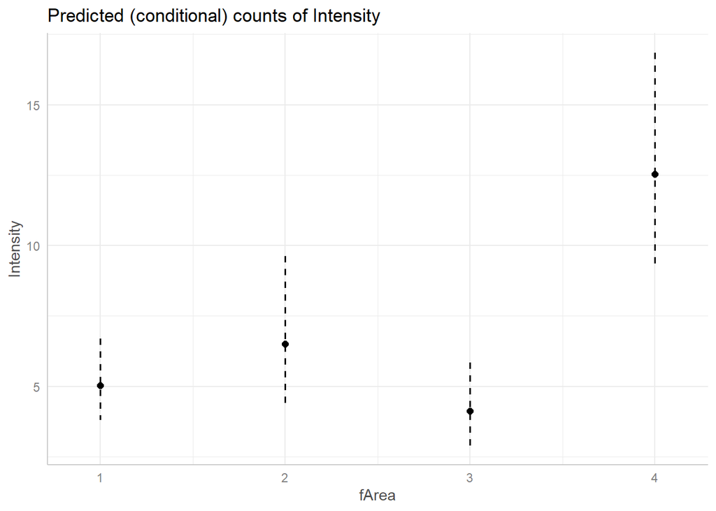

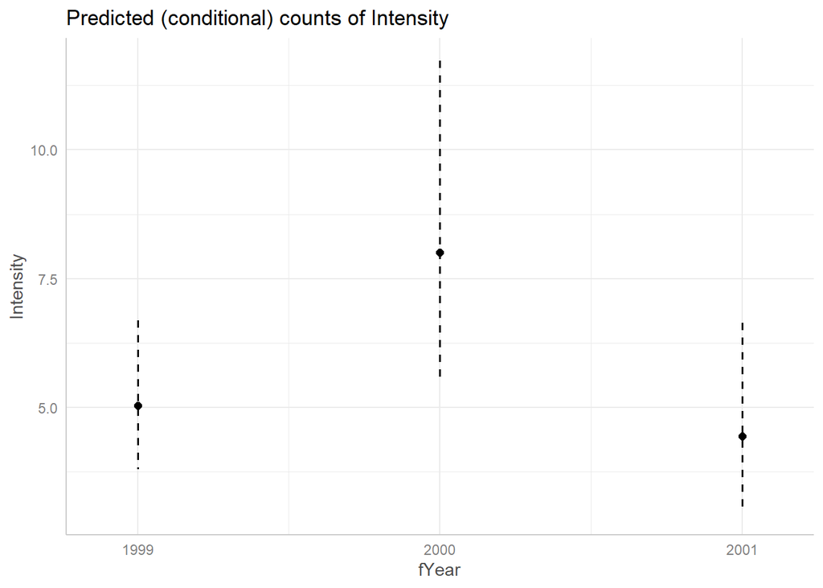

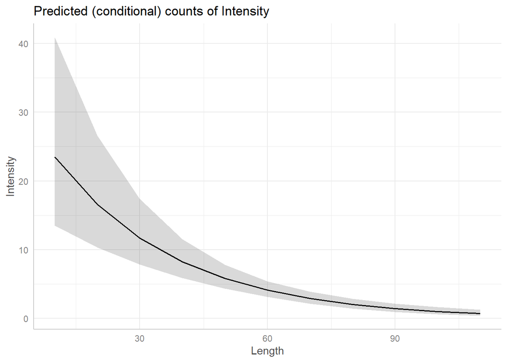

```r
# plots the predicted count data
plot(ggpredict(Zinb3))
```

```
## Ignoring unknown labels:
## • linetype : "fYear"
## • shape : "fYear"
```

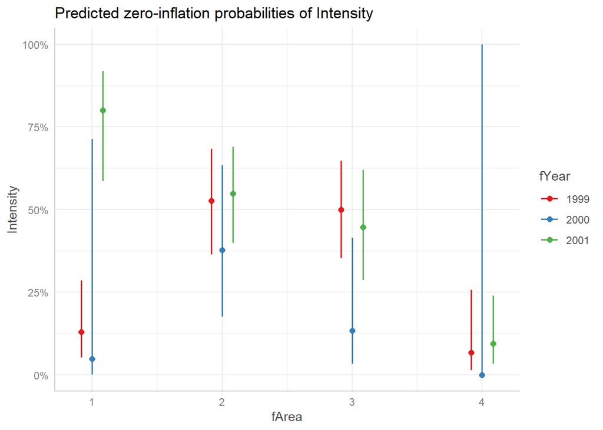

```r
# plot the predicted zero-inflated probabilities
plot(ggpredict(Zinb1, terms=c("fArea", "fYear"), type="zi_prob"))
```

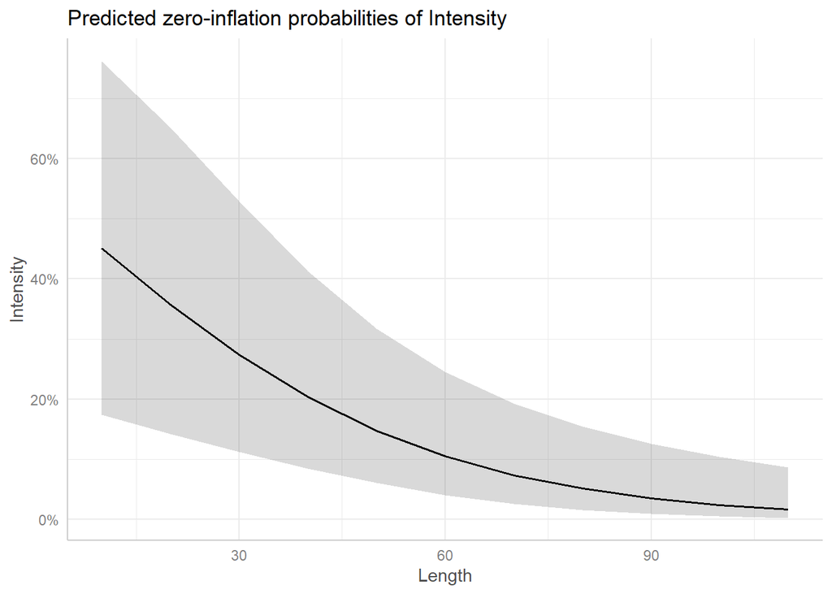

```r
plot(ggpredict(Zinb1, terms=c("Length"), type="zi_prob"))
```

**Model Interpretation**

**Count model:**  
- Parasite counts were highest in **Area 4** and **Year 2000**, especially among **smaller fish**.  
- Area 4 had an **incidence rate ratio (IRR)** of 2.49 compared to Area 1, meaning a **149% higher infection rate**.  
- Year 2000 showed a **59% increase** in infection rate over 1999.  
- Fish length had an IRR of 0.97, indicating a **3% decrease** in infection rate per unit increase in length.

**Zero-inflation model:**  
- The **probability of false zeros** decreased with increasing fish length — smaller fish were more likely to be misclassified as uninfected.  
- The probability of false zeros also varied by **Area × Year**, with the **highest risk** in **Area 1, Year 2001**.  
- For odds ratios < 1, use: Percent change = (1 / odds - 1) × 100

### Hurdle models

Hurdle models estimate two separate parts: - A **binary model** (zero vs. positive) - A **truncated count model** (for positives only)

You might use this is you think of the process that gnerates the zeros versus ones is very different.

The nice part about usign glmmTMB is that you can also just a run a simple truncated model – if the ziformula was left blank it would just be ignored and then you are jut fitting the truncated family with no zer dispersion!!

### Fit Hurdle Model (ZAP and ZANB)

```r
Hurd1 <- glmmTMB(Intensity ~  fArea*fYear + Length, ziformula = ~  fArea*fYear + Length,
                    data = ParasiteCod2, family = "truncated_poisson")

Hurd2 <- glmmTMB(Intensity ~  fArea*fYear + Length, ziformula = ~  fArea*fYear + Length,
                    data = ParasiteCod2, family = "truncated_nbinom2")
```

### Compare models

```r
AIC(Hurd1, Hurd2)
```

```
##       df       AIC
## Hurd1 26 13687.576
## Hurd2 27  4937.085
```

### Model selection

```r
Hurd3 <- glmmTMB(Intensity ~  fArea*fYear, ziformula = ~  fArea*fYear + Length,
                    data = ParasiteCod2, family = "truncated_nbinom2")

Hurd4 <- glmmTMB(Intensity ~  fArea+fYear + Length, ziformula = ~  fArea*fYear + Length,
                    data = ParasiteCod2, family = "truncated_nbinom2")

Hurd5 <- glmmTMB(Intensity ~  fArea*fYear + Length, ziformula = ~  fArea*fYear,
                    data = ParasiteCod2, family = "truncated_nbinom2")

Hurd6 <- glmmTMB(Intensity ~  fArea*fYear + Length, ziformula = ~  fArea+fYear,
                    data = ParasiteCod2, family = "truncated_nbinom2")

AIC(Hurd2, Hurd3,Hurd4,Hurd5,Hurd6)
```

```
##       df      AIC
## Hurd2 27 4937.085
## Hurd3 26 4971.695
## Hurd4 21 4936.393
## Hurd5 26 4937.316
## Hurd6 20 4978.562
```

```r
Hurd7 <- glmmTMB(Intensity ~  fArea+fYear + Length, ziformula = ~  fArea*fYear,
                    data = ParasiteCod2, family = "truncated_nbinom2")
Hurd8 <- glmmTMB(Intensity ~  fArea+fYear + Length, ziformula = ~  fArea+fYear,
                    data = ParasiteCod2, family = "truncated_nbinom2")

AIC(Hurd7, Hurd8)
```

```
##       df      AIC
## Hurd7 20 4936.624
## Hurd8 14 4977.870
```

```r
#Hurd7 is the final model
```

### Visualize model predictions

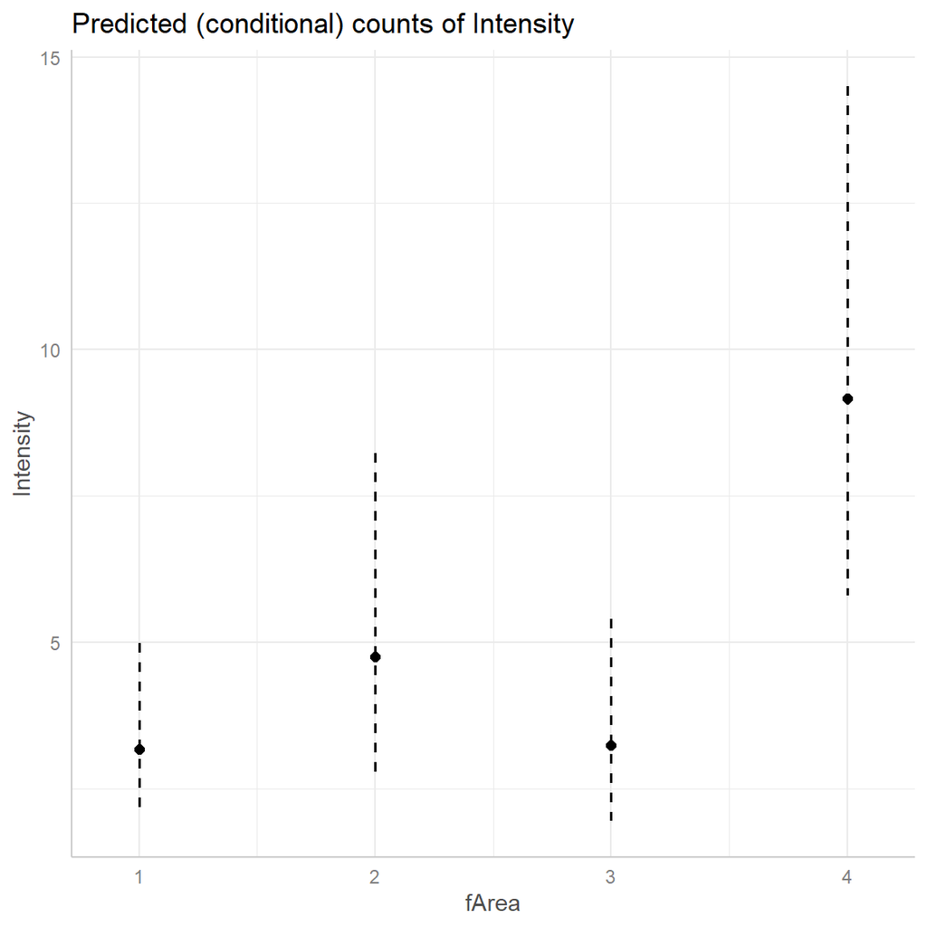

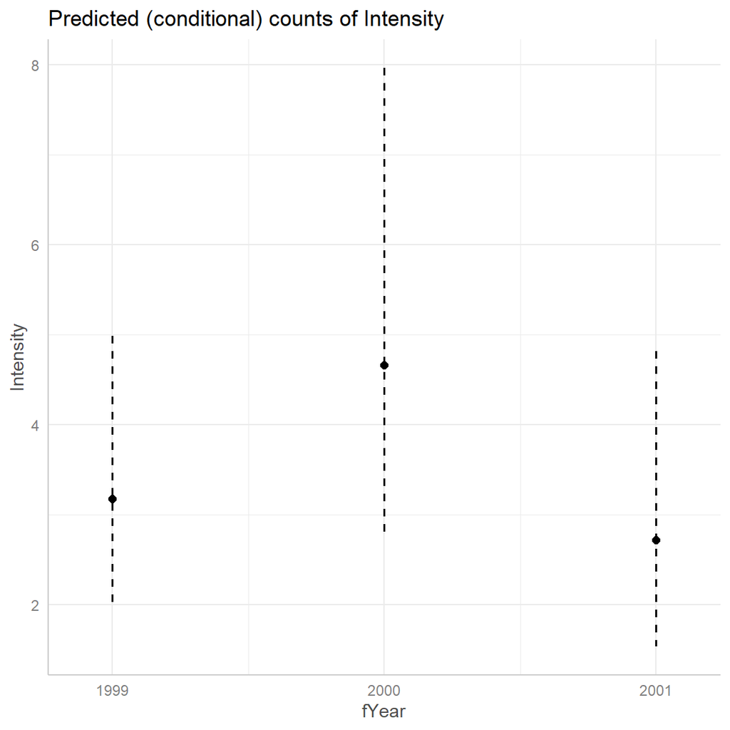

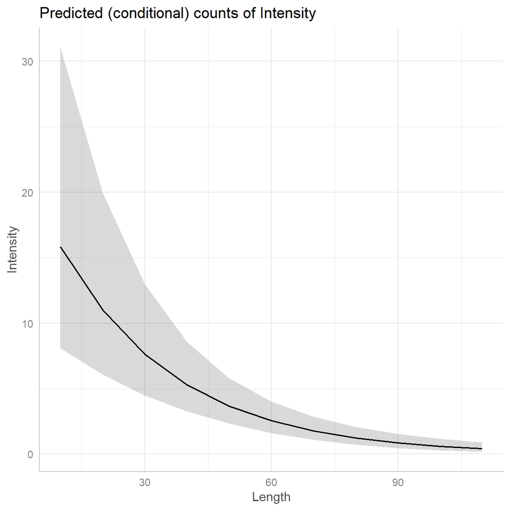

```r
plot(ggpredict(Hurd7))
```

```
## Ignoring unknown labels:
## • linetype : "fYear"
## • shape : "fYear"
```

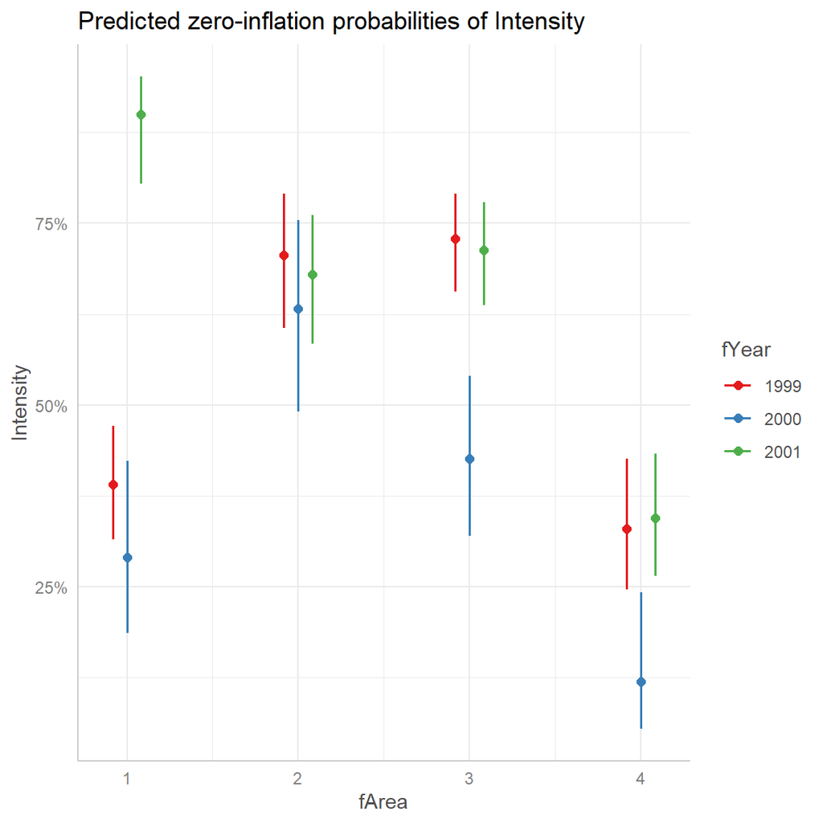

```r
plot(ggpredict(Hurd7, terms = c("fArea", "fYear"), type = "zi_prob"))
```

## Exercises

### 1. Fishing

These data (fish.csv) come from a survey of 250 groups that visited a state park. The dataset includes: - `count`: number of fish caught by the group - `child`: number of children in the group - `persons`: total number of people in the group - `camper`: 1 if the group brought a camper, 0 otherwise

1. Visualize the distribution of fish counts. What does the distribution look like?
2. Fit a Poisson and Negative Binomial model without zero-inflation to test how count is impacted by child, persons, and camper. Compare the models using AIC.
3. Fit a zero-inflated Poisson model with `child` as the predictor of zero inflation. Interpret the zero-inflation part.
4. Fit a zero-inflated Negative Binomial model with `child` in the zero-inflation part. Is the fit improved?
5. Compare AIC for the Poisson, Negative Binomial, and both zero-inflated models. Which model is best?
6. For the best model, interpret the coefficients. What variables increase or decrease the number of fish caught?
7. What does the zero-inflation part tell you? Are groups with more children more likely to have false zeros?
8. Plot simulated residuals using DHARMa for the best model. Do the residuals indicate problems?
9. Plot residuals against `child`, `camper`, and `persons`. Are there any patterns?
10. What are your final conclusions about what drives fish count and zero-inflation in this dataset?

### 2. Squirrel behavior

For this exercise, you will consider the nuts data set (nuts.csv). These data were originally reported by Flaherty et al (2012). Researchers recorded information about squirrel behavior and forest attributes across various plots in Scotland’s Abernathy Forest. The study focused on the following variables:

cones = number of cones stripped by red squirrels per plot  
sntrees = standardized number of trees per plot  
sheight = standardized mean tree height per plot  
scover = standardized percentage of canopy cover per plot

1. Fit and compare multiple count models:
- Fit a Poisson model and a negative binomial model relating `cones` to `sntrees`, `sheight`, and `scover`.
- Fit zero-inflated versions of each, assuming constant zero-inflation (`ziformula = ~1`).
- Fit a hurdle model using both `truncated_poisson` and `truncated_nbinom2`. Assume a constant zero inflation.
- Compare all models using AIC.
2. Plot and interpret the two best models. Explain how parameters differ between a zero-inflated model and the model without zero-inflation. What do the zero-inflation model coefficients mean?
3. Assess model fit using diagnostic plots. Plot residuals against fitted values and each predictor.